# Tidybiology: Class 5 Report Exercise

My disease of interest is acute myeloid leukemia

## Study Background

These data were obtained from a published study that by Sobecks et al. called [Cytomegalovirus Reactivation After Matched Sibling Donor Reduced-Intensity Conditioning Allogeneic Hematopoietic Stem Cell Transplant Correlates With Donor Killer Immunoglobulin-like Receptor Genotype](http://www.ectrx.org/forms/ectrxcontentshow.php?year=2011&volume=9&issue=1&supplement=0&makale_no=0&spage_number=7&content_type=FULL%20TEXT)

To learn more about the study and the data produced, run `?cytomegalovirus` in your console

# Objective

The goal of this study was to determine if the number of donor activating killer immunoglobulin-like receptors (aKIRs) influenced reactivation of CMV after T-cell replete, matched sibling donor reduced-intensity conditioning allogeneic hematopoietic stem cell transplant

Donors were divided into two groups - those with either 1-4 or 5-6 alpha killer immunoglobulin-like receptors (recoded as “low” and “high” respectively by us)

CMV reactivation status is either 0 (“no”) or 1 (“yes”)

## Visualizing the relationship between the number of aKIR genes and CMV reactivation

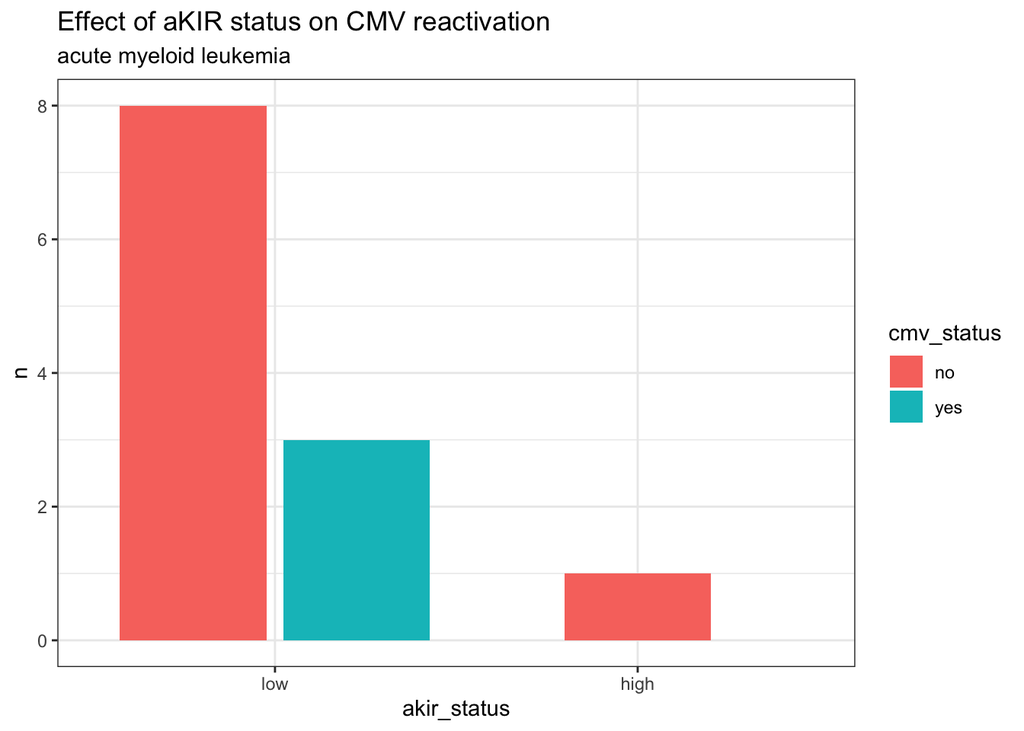

## Analysis Summary

My disease of interest is acute myeloid leukemia. There were 12 patients with this disease in this study. The total number of patients afflicted by this disease who experienced CMV reactivation was 3, versus 9 who did not. There were 7 women and 5 men with this disease, compared to 34 women and 30 men overall